# Session 3: tidyverse and publication-ready figures

Nils

2020-04-07

In this session, I will go through the concept of tidy data in R. Tidy data is broadly defined as having individual samples in the rows of a data matrix while the columns define variables (or features) describing the samples https://en.wikipedia.org/wiki/Tidy_data. This is the standard format for any sort of statistical analysis.

We will also discuss the `long` and `wide` data format.

**Disclaimer:** Tidyverse offers functionality, which is quite similar to base R’s behaviour but with higher efficiency and less typing. However, for beginners it can get confusing to mix both ways of programming.

The `tidyverse` library offers a set of libraries that handle tidy data in R:

```r
library(tidyverse)
```

From the full set of tools, I will be talking about the `tibble`, `readr`, `tidyr`, `dplyr`, `magrittr` and `ggplot2` package in more detail. This tutorial will closely follow examples provided in the [R for data science book](https://r4ds.had.co.nz/index.html).

The general workflow for data analysis in R is:

1. Reading in your data
2. Tidying your data
3. Transforming your data
4. Visualizing your data
5. Modelling your data

In the last session, we have talked about different ways of reading in the data.

## Introduction

To understand the following session, I will need to introduce a new data type: tibble

### Tibbles

Tibbles are an enhanced version of the base R `data.frame` but with similar functionality.

```r
data(iris)
iris
as_tibble(iris)
```

Only the first 10 entries are shown.

Tibbles can be created using the `tibble` function:

| x | y | z |
| --- | --- | --- |
| 1 | 1 | 2 |
| 2 | 1 | 5 |
| 3 | 1 | 10 |
| 4 | 1 | 17 |
| 5 | 1 | 26 |

Coercion into `data.frame` works via `as.data.frame`:

| x | y | z |
| --- | --- | --- |
| 1 | 1 | 2 |
| 2 | 1 | 5 |
| 3 | 1 | 10 |
| 4 | 1 | 17 |
| 5 | 1 | 26 |

Subsetting is enhanced for `tibble` compared to `data.frames` and `stringAsFactor` argument is ignored.

| abc | xyz |
| --- | --- |
| 1 | a |
| 2 | b |
| 3 | c |

## Reading in data

We have discussed the base R `read.table` and `read.csv` function in the last session. Now we will work with the `readr` package to read data into tibbles with a few enhancements:

```r
cur_file <- readr::read_csv("~/Github/IntroDataAnalysis/Data/iris.csv")
cur_file

cur_file <- readr::read_csv("~/Github/IntroDataAnalysis/Data/iris.csv", col_names = FALSE)
cur_file

cur_file <- readr::read_csv("~/Github/IntroDataAnalysis/Data/iris.csv", na = "setosa")
cur_file
```

By default, `readr` reads in the first 1000 lines of the file and for each column guesses the data type. This behaviour can be overwritten:

| Sepal.Length | Sepal.Width | Petal.Length | Petal.Width | Species |
| --- | --- | --- | --- | --- |
| 5.1 | 3.5 | 1.4 | 0.2 | setosa |
| 4.9 | 3 | 1.4 | 0.2 | setosa |
| 4.7 | 3.2 | 1.3 | 0.2 | setosa |
| 4.6 | 3.1 | 1.5 | 0.2 | setosa |
| 5 | 3.6 | 1.4 | 0.2 | setosa |
| 5.4 | 3.9 | 1.7 | 0.4 | setosa |
| 4.6 | 3.4 | 1.4 | 0.3 | setosa |
| 5 | 3.4 | 1.5 | 0.2 | setosa |
| 4.4 | 2.9 | 1.4 | 0.2 | setosa |
| 4.9 | 3.1 | 1.5 | 0.1 | setosa |

[output cut: 140 more lines]

Extension to previous session:

At this point it is also usefult to mention the `saveRDS` and `readRDS` function. They save individual R objects “as is” on disc:

```r
cur_file <- readr::read_csv("~/Github/IntroDataAnalysis/Data/iris.csv")
saveRDS(cur_file, "~/Github/IntroDataAnalysis/Data/iris.rds")
cur_file_2 <- readRDS("~/Github/IntroDataAnalysis/Data/iris.rds")
cur_file_2
```

## Tidying up your data

This section will introduce the `tidyr` package. A tidy dataset is defined as:

1. Each variable must have its own column.
2. Each observation must have its own row.
3. Each value must have its own cell.

An example is given by the follwing dataset:

| country | year | cases | population |
| --- | --- | --- | --- |
| Afghanistan | 1999 | 745 | 19987071 |
| Afghanistan | 2000 | 2666 | 20595360 |
| Brazil | 1999 | 37737 | 172006362 |
| Brazil | 2000 | 80488 | 174504898 |
| China | 1999 | 212258 | 1272915272 |
| China | 2000 | 213766 | 1280428583 |

However, datasets often come in all types of forms that do not follow these rules (messy data). The `tidyr` package provides the `pivot_longer` and `pivot_wider` function to handle the ransformation from messy to tidy data. Similar functions are exported from the `reshape2` and `data.table` package (`melt`, `acast`, `dcast`).

Here is an example:

|  | country | 1999 | 2000 |
| --- | --- | --- | --- |
| 1 | Afghanistan | 745 | 2666 |
| 2 | Brazil | 37737 | 80488 |
| 3 | China | 212258 | 213766 |

The `pivot_longer` function provides a long format tibble storing individual observations in rows and variables in columns.

```r
reshape2::melt(table4a)
```

| country | variable | value |
| --- | --- | --- |
| Afghanistan | 1999 | 745 |
| Brazil | 1999 | 37737 |
| China | 1999 | 212258 |
| Afghanistan | 2000 | 2666 |
| Brazil | 2000 | 80488 |
| China | 2000 | 213766 |

Another example is the following dataset:

| country | year | type | count |
| --- | --- | --- | --- |
| Afghanistan | 1999 | cases | 745 |
| Afghanistan | 1999 | population | 19987071 |
| Afghanistan | 2000 | cases | 2666 |
| Afghanistan | 2000 | population | 20595360 |
| Brazil | 1999 | cases | 37737 |
| Brazil | 1999 | population | 172006362 |
| Brazil | 2000 | cases | 80488 |
| Brazil | 2000 | population | 174504898 |
| China | 1999 | cases | 212258 |
| China | 1999 | population | 1272915272 |

[output cut: 2 more lines]

To make the data wider, the `tidyr` package provides the `pivot_wider` function:

| country | year | cases | population |
| --- | --- | --- | --- |
| Afghanistan | 1999 | 745 | 19987071 |
| Afghanistan | 2000 | 2666 | 20595360 |
| Brazil | 1999 | 37737 | 172006362 |
| Brazil | 2000 | 80488 | 174504898 |
| China | 1999 | 212258 | 1272915272 |
| China | 2000 | 213766 | 1280428583 |

The `tidyr` package can also be used to split and merge columns.

As an example, we use this messy data:

|  | country | year | rate |
| --- | --- | --- | --- |
| 1 | Afghanistan | 1999 | 745/19987071 |
| 2 | Afghanistan | 2000 | 2666/20595360 |
| 3 | Brazil | 1999 | 37737/172006362 |
| 4 | Brazil | 2000 | 80488/174504898 |
| 5 | China | 1999 | 212258/1272915272 |
| 6 | China | 2000 | 213766/1280428583 |

The `rate` column can be split using the `separate` operation:

| country | year | cases | populations |
| --- | --- | --- | --- |
| Afghanistan | 1999 | 745 | 19987071 |
| Afghanistan | 2000 | 2666 | 20595360 |
| Brazil | 1999 | 37737 | 172006362 |
| Brazil | 2000 | 80488 | 174504898 |
| China | 1999 | 212258 | 1272915272 |
| China | 2000 | 213766 | 1280428583 |

On the other hand, `tidyr` can also unite data:

| country | year | rate |
| --- | --- | --- |
| Afghanistan | 1999 | 745/19987071 |
| Afghanistan | 2000 | 2666/20595360 |
| Brazil | 1999 | 37737/172006362 |
| Brazil | 2000 | 80488/174504898 |
| China | 1999 | 212258/1272915272 |
| China | 2000 | 213766/1280428583 |

## The pipe operator

The `magrittr` package exports a set of operators taht facilitates the concatenations of operations in R. At this point, I only want to mention the `%>%` forward pipe operator.

This allows us use functions in the following way:

```r
table5 %>% unite(col = "year", century, year, sep = "")
```

From now on, we will only use the pipe operator.

## Data transformation

The `dplyr` package offers five essential functions to perform data transformations in R: `filter`, `arrange`, `select`, `mutate` and `summarise`

These operations can be used within pipes.

As an example, we take the `nycflights13::flights` dataset.

### Filter

The `filter` function filters a `data.frame` or `tibble` based on it’s content.

| year | month | day | dep_time | sched_dep_time | dep_delay | arr_time | sched_arr_time | arr_delay | carrier | flight | tailnum | origin | dest | air_time | distance | hour | minute | time_hour |
| --- | --- | --- | --- | --- | --- | --- | --- | --- | --- | --- | --- | --- | --- | --- | --- | --- | --- | --- |
| 2013 | 1 | 1 | 517 | 515 | 2 | 830 | 819 | 11 | UA | 1545 | N14228 | EWR | IAH | 227 | 1400 | 5 | 15 | 2013-01-01 05:00:00 |
| 2013 | 1 | 1 | 533 | 529 | 4 | 850 | 830 | 20 | UA | 1714 | N24211 | LGA | IAH | 227 | 1416 | 5 | 29 | 2013-01-01 05:00:00 |
| 2013 | 1 | 1 | 542 | 540 | 2 | 923 | 850 | 33 | AA | 1141 | N619AA | JFK | MIA | 160 | 1089 | 5 | 40 | 2013-01-01 05:00:00 |
| 2013 | 1 | 1 | 544 | 545 | -1 | 1004 | 1022 | -18 | B6 | 725 | N804JB | JFK | BQN | 183 | 1576 | 5 | 45 | 2013-01-01 05:00:00 |
| 2013 | 1 | 1 | 554 | 600 | -6 | 812 | 837 | -25 | DL | 461 | N668DN | LGA | ATL | 116 | 762 | 6 | 0 | 2013-01-01 06:00:00 |
| 2013 | 1 | 1 | 554 | 558 | -4 | 740 | 728 | 12 | UA | 1696 | N39463 | EWR | ORD | 150 | 719 | 5 | 58 | 2013-01-01 05:00:00 |
| 2013 | 1 | 1 | 555 | 600 | -5 | 913 | 854 | 19 | B6 | 507 | N516JB | EWR | FLL | 158 | 1065 | 6 | 0 | 2013-01-01 06:00:00 |
| 2013 | 1 | 1 | 557 | 600 | -3 | 709 | 723 | -14 | EV | 5708 | N829AS | LGA | IAD | 53 | 229 | 6 | 0 | 2013-01-01 06:00:00 |
| 2013 | 1 | 1 | 557 | 600 | -3 | 838 | 846 | -8 | B6 | 79 | N593JB | JFK | MCO | 140 | 944 | 6 | 0 | 2013-01-01 06:00:00 |
| 2013 | 1 | 1 | 558 | 600 | -2 | 753 | 745 | 8 | AA | 301 | N3ALAA | LGA | ORD | 138 | 733 | 6 | 0 | 2013-01-01 06:00:00 |

[output cut: 990 more lines]

### Arrange

The `arrange` function orderes data.frames and tibbles:

```r
flights %>% arrange(year, month, dep_time)

# Descending order
flights %>% arrange(desc(month))

# Base R
flights[order(flights$month, decreasing = TRUE),]
```

### Select

The `select` function selects columns in useful ways.

```r
flights %>% select(year, month)

# Everything between year and day
flights %>% select(year:day)

# String matching
flights %>% select(starts_with("dep"))
flights %>% select(contains("dep"))

# Base R
flights[,grep("^dep", colnames(flights))]
flights[,grep("dep", colnames(flights))]
```

### Mutate

The `mutate` function adds new columns to a dataset by performing an operation on existing columns:

| year | month | day | dep_delay | arr_delay | distance | air_time | gain | speed |
| --- | --- | --- | --- | --- | --- | --- | --- | --- |
| 2013 | 1 | 1 | 2 | 11 | 1400 | 227 | -9 | 370.0441 |
| 2013 | 1 | 1 | 4 | 20 | 1416 | 227 | -16 | 374.2731 |
| 2013 | 1 | 1 | 2 | 33 | 1089 | 160 | -31 | 408.3750 |
| 2013 | 1 | 1 | -1 | -18 | 1576 | 183 | 17 | 516.7213 |
| 2013 | 1 | 1 | -6 | -25 | 762 | 116 | 19 | 394.1379 |
| 2013 | 1 | 1 | -4 | 12 | 719 | 150 | -16 | 287.6000 |
| 2013 | 1 | 1 | -5 | 19 | 1065 | 158 | -24 | 404.4304 |
| 2013 | 1 | 1 | -3 | -14 | 229 | 53 | 11 | 259.2453 |
| 2013 | 1 | 1 | -3 | -8 | 944 | 140 | 5 | 404.5714 |
| 2013 | 1 | 1 | -2 | 8 | 733 | 138 | -10 | 318.6957 |

[output cut: 990 more lines]

The `transmute` function only returns the newly generated entries.

| gain | speed |
| --- | --- |
| -9 | 370.0441 |
| -16 | 374.2731 |
| -31 | 408.3750 |
| 17 | 516.7213 |
| 19 | 394.1379 |
| -16 | 287.6000 |
| -24 | 404.4304 |
| 11 | 259.2453 |
| 5 | 404.5714 |
| -10 | 318.6957 |

[output cut: 990 more lines]

## Summarise

The `summarise` function computes summary statistics on individual columns:

| delay | delay_var |
| --- | --- |
| 12.63907 | 1616.849 |

## Group_by

The perform fast and efficient data transformations, the `group_by` function comes in handy:

| year | month | day | delay | delay_var |
| --- | --- | --- | --- | --- |
| 2013 | 1 | 1 | 11.54892601 | 2048.5896 |
| 2013 | 1 | 2 | 13.85882353 | 1384.4897 |
| 2013 | 1 | 3 | 10.98783186 | 989.5646 |
| 2013 | 1 | 4 | 8.95159516 | 769.1893 |
| 2013 | 1 | 5 | 5.73221757 | 662.2522 |
| 2013 | 1 | 6 | 7.14801444 | 536.7720 |
| 2013 | 1 | 7 | 5.41720430 | 732.7536 |
| 2013 | 1 | 8 | 2.55307263 | 374.1759 |
| 2013 | 1 | 9 | 2.27647715 | 2197.0284 |
| 2013 | 1 | 10 | 2.84499462 | 1924.0147 |

[output cut: 355 more lines]

Let’s build more complex pipes:

```r
flights %>%
    filter(dest == "DEN") %>%
    mutate(speed = (distance / air_time) * 60) %>%
    group_by(year, month, day) %>%
    summarise(mean_speed = mean(speed, na.rm = TRUE)) %>%
    arrange(desc(mean_speed))
```

## Visualize your data

In the next section, we will use the `ggplot2` package to visualize the data.

Each `ggplot` call is structured in the same way:

As a simple example, we will use a smaller dataset:

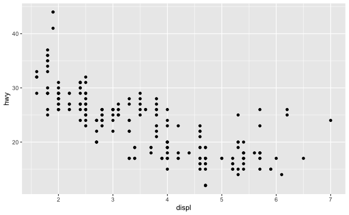

`displ` is the cars’ engine size and `hwy` is the fuel efficiency on a highway.

The `+` operator let’s you add layers to a plot

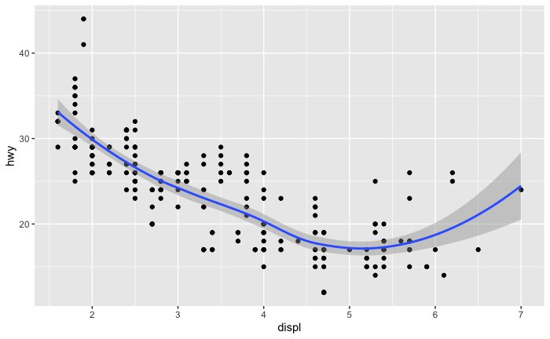

### Changing the aesthetics

There are multiple ways of adjusting the visual output INSIDE the `aes()` call.

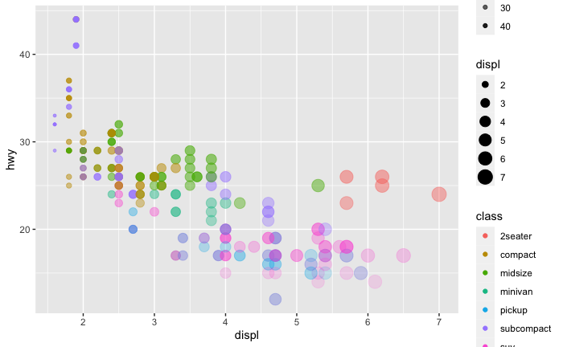

There are also manipulations possible that you need to set OUTSIDE the `aes()` call.

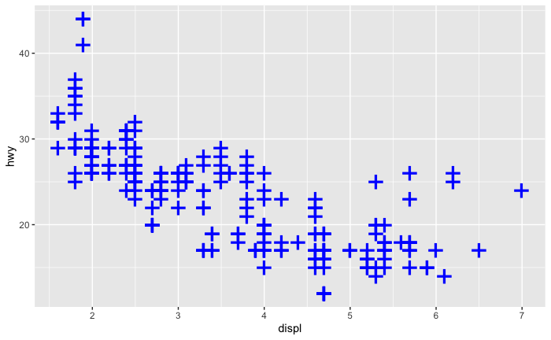

## Facetting

Using `ggplot2`, you can split the plot into multiple sub-plots using `facet_wrap` for single variables and `facet_grid` for two variables:

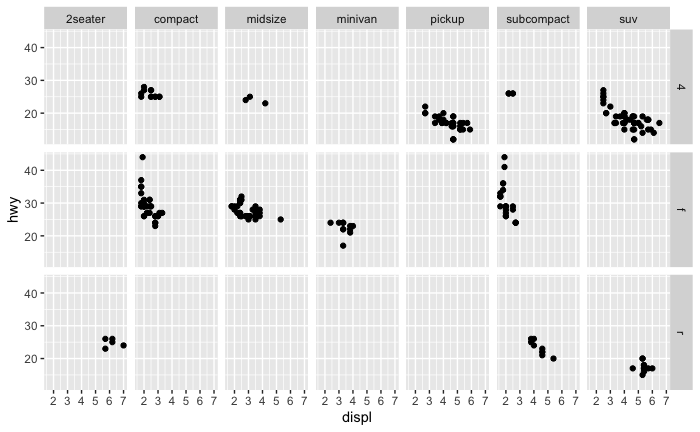

### Other examples of plots

```
Ignoring unknown parameters: outlier.colour
```

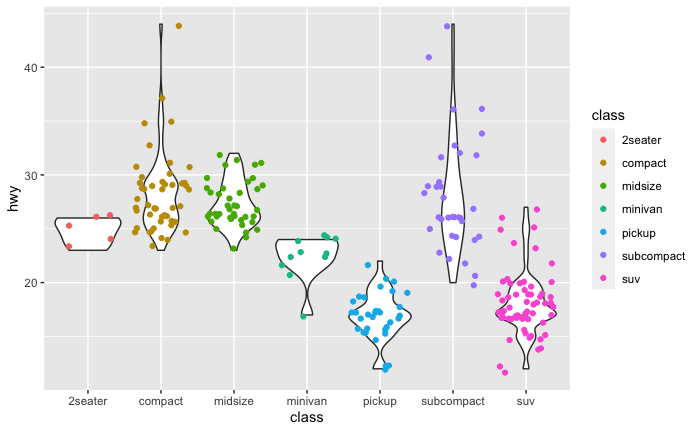

```r
ggplot(data = mpg) +
    geom_violin(mapping = aes(x = class, y = hwy),
                 outlier.color = NA) +
    geom_jitter(mapping = aes(x = class, y = hwy, colour = class))
```

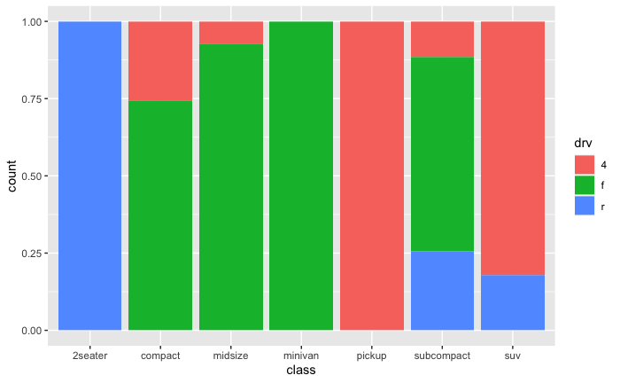

### Setting the theme and scales

All visual properties of the plots can be changed using `theme` and `*_scale`

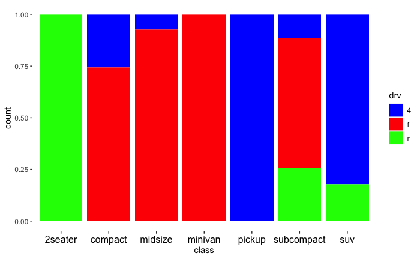

### Displaying multiple plots

Finally, I will highlight the functionality of the `cowplot` and `patchwork` package to display multiple plots side-by-side:

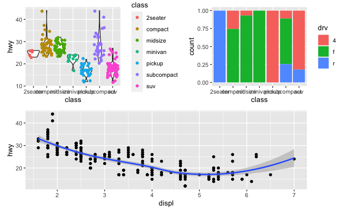